# Probing the senescence-induced senescence hypothesis

Stephen Malina

12/7/2020

# 1 Introduction

Cellular senescence is increasingly believed to play an important role in the aging process. Senescent cells (SnCs) are cells that can no longer divide but continue to limp along rather than actually die. In young, healthy organisms, senescent cells can play a positive role in arresting tumor growth and healing wounds (Ricón 2020; He and Sharpless 2017; Krtolica et al. 2001). However, increasing evidence points to senescent cells contributing to the aging process via slowing stem cell growth and tissue regeneration and increasing inflammation in older organisms (Campisi and Di Fagagna 2007).

A characteristic pattern that accompanies the shift in roles is an increase in relative abundance of and slowing down of turnover of senescent cells. Understanding and intervening on cellular senescence requires unraveling the puzzle behind this change in dynamics Evidence from Nelson et al. (2012) suggests that this process partly results from a “bystander effect” in which senescent cells induce nearby healthy cells into senescence (senescence-induced senescence, SIS).

# 2 Methods

We build a Bayesian ODE-based model of SnC growth dynamics based on a pair of mouse SnC time-series datasets using stan (Carpenter et al. 2017). We compare our model to Bayesian versions of two previously-published models using Bayes Factors (Gronau, Singmann, and Wagenmakers 2020), leave-one-out cross-validation (LOO-CV) (Yao et al. 2017), and an extrapolation test. All of our code and data are available on Github.

## 2.1 Datasets

### 2.1.1 Longitudinal Dataset

Our primary dataset measures SnC abundance in 32 mice over their entire lifespan (80, i.e. ~1.54 years).

### 2.1.2 Pulse Dataset

## 2.2 Models

## 2.3 Saturated Removal (SR) and Unsaturated Removal (USR) base models

As a first step towards building and assessing a model that includes senescence-induced senescence, we re-fit two existing models (Karin et al. 2019) of senescent cell growth on a longitudinal senescent cell dataset initially produced by Burd et al. (2013) and pre-processed (from images) by Karin et al. (2019).

In their paper, Karin et al. (2019) apply a maximum likelihood framework and parameter grid search to fit 16 ODE-based models of senescent cell growth. Each of their 16 models was derived by selecting a subset of parameters from the following ‘full’ model of senescent cell growth with time/age,

$$\begin{equation}
\frac{\rm{d}C}{\rm{d}t} = \underbrace{(\eta_0 + \eta_1 * t)(1 + \eta_2 * C)}_{\text{production}}
- \underbrace{\frac{\beta_0 - \beta_1 * t}{1 + \beta_2 * C} * C}_{\text{removal}} +
\underbrace{\sqrt{2 \epsilon} * \xi_t}_{\text{noise}}.
\tag{2.1}
\end{equation}$$

In Karin et al. (2019), the best-performing model variant, the saturated removal (SR) model, got rid of the senescence-induced senescence term but otherwise left the model as-is. The best-performing variant without the saturated removal term ($\beta_2$), i.e. the unsaturated removal (USR) model, also excluded the senescence-induced senescence term in its growth rate expression.

## 2.4 Reproducing the base models in the Bayesian framework

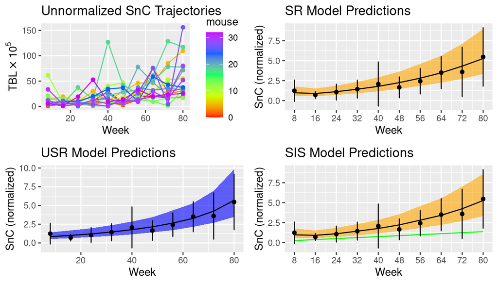

Figure 2.1: Unnormalized senescent cell (SnC) abundance trajectories for each mouse (top left). Retrodictions and 5%/95% credible intervals for SnC mean abundance predicted by SR, USR, and SIS models (top right, bottom left, bottom right) respectively. Lines denote posterior median, dots denote observed mean abundance with error bars representing sample standard error. Green line in the SIS graph denotes estimated long-lived SnC abundance.

Although the SR model’s full posterior fits the data meaningfully better than the USR model’s, as Figure 2.1 shows, both models’ credible intervals and posterior means mostly capture the observed data’s evolution through time. This suggests that the maximum likelihood approach may have underestimated the quality of the USR model even if it correctly captures the superiority of the SR model.

### 2.4.1 Long-lived SnC senescence-induced senescence (SIS) model

As mentioned, the original full model included a term for SIS. However, the model treated SIS as growing as a function of overall SnC count and total SnC growth rate. Intuitively, given a long enough time this would inevitably lead to exponential growth of the number of senescent cells, which we don’t observe. As suggested by Van Deursen (2014), it’s instead possible that a small fraction of senescent cells both turn over more slowly and induce senescence in their neighbors, but the majority do not.

To test this hypothesis, we can modifythe SR model by replacing the current time-dependent growth rate term with a time-dependent long-lived cell SIS term:

$$\begin{align}
\frac{\rm{d}L}{\rm{d}t} &= \alpha \\
\frac{\rm{d}C}{\rm{d}t} &= (\eta_0 + \eta_2 * L) -
\frac{\beta_0 - \beta_1 * t}{1 + \beta_2 * C}.
\tag{2.2}
\end{align}$$

In equation (2.2), $\frac{\rm{d}L}{\rm{d}t}$ denotes the time rate of change of (latent) long-lived senescent cell count. Solving for $L$ this becomes
$$\begin{equation}
\frac{\rm{d}C}{\rm{d}t} = (\eta_0 + \eta_2 * l + \eta_2 * \alpha t) -
\frac{\beta_0 - \beta_1 * t}{1 + \beta_2 * C} * C.
\tag{2.3}
\end{equation}$$
where $l$ denotes the long-lived SnC abundance and $\alpha t$ the (assumed to be linear) increase as a function of time.

# 3 Results

## 3.1 Long-lived SnC SIS model fits the longitudinal dataset better than the base models

Our new long-lived SnC SIS model accurately describes the SnC growth dynamics of the longitudinal dataset. In fact, we find that it fits the data, as measured by both Bayes Factor and LOO-cross validation, better (under a uniform prior between models) than the SR model (Bayes Factor of 25 and slightly higher ELPD-LOO). This suggests that long-lived senescent cell SIS may partially explain senescent cell dynamics when combined with saturated removal.

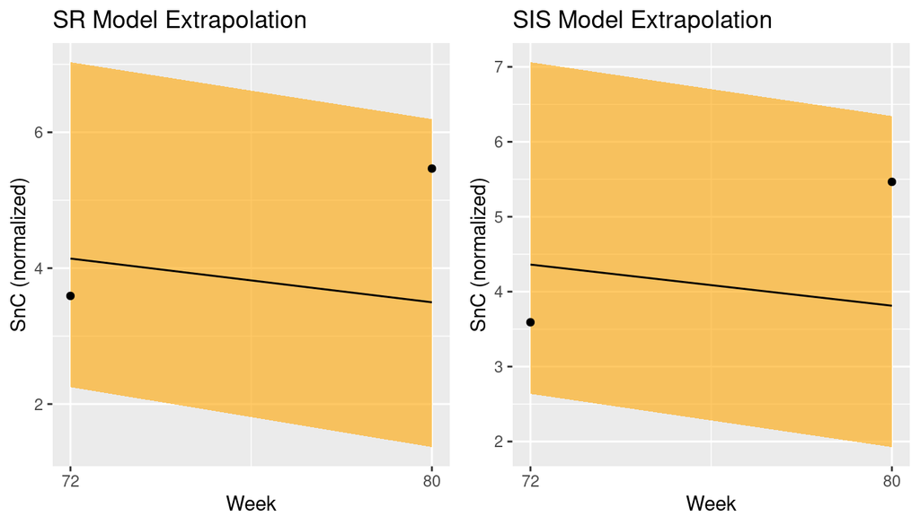

Figure 3.1: SR and SIS model predictive distributions for held-out weeks 72 and 80. As in Figure 1, dots denote true abundance values, lines predictive medians, and yellow bars 5%/95% predictive intervals. Both models incorrectly predict a slowdown in SnC growth but capture both points in their predictive distributions.

## 3.2 Long-lived SnC SIS model doesn’t fit the pulse data as well as the SR model

Unlike with the longitudinal dataset, on the pulse dataset, the SIS model’s increased complexity does not seem to improve the model’s fit. As measured by Bayes Factor, the SR model is approximately twice as probable as the SIS model with respect to the pulse data. We admittedly didn’t predict this before running the model. In retrospect, it can be partially explained by a combination of the pulse dataset having been generated in a way that likely would only increase the number of acute SnCs, not long-lived ones, and the long-lived cell SIS not contributing meaningful growth in the relatively short timescale of the pulse dataset. In spite of this justification, this finding should be taken as providing some, albeit weak evidence, against the long-lived SIS hypothesis.

# 4 Discussion

## 4.1 Strengths and Limitations

## 4.2 Future Work

### 4.2.1 Computational

### 4.2.2 Experimental

# 5 Appendix

## 5.1 Differences between our and the original model

### 5.1.1 Normally-distributed error with ODE vs. stochastic differential equation

### 5.1.2 Fully Bayesian vs. Maximum Likelihood model

### 5.1.3 Auto-catalysis term vs. SIS term

# References

Burd, Christin E, Jessica A Sorrentino, Kelly S Clark, David B Darr, Janakiraman Krishnamurthy, Allison M Deal, Nabeel Bardeesy, Diego H Castrillon, David H Beach, and Norman E Sharpless. 2013. “Monitoring Tumorigenesis and Senescence in Vivo with a p16INK4a-Luciferase Model.” *Cell* 152 (1-2): 340–51.

Campisi, Judith, and Fabrizio D’Adda Di Fagagna. 2007. “Cellular Senescence: When Bad Things Happen to Good Cells.” *Nature Reviews Molecular Cell Biology* 8 (9): 729–40.

Carpenter, Bob, Andrew Gelman, Matthew D Hoffman, Daniel Lee, Ben Goodrich, Michael Betancourt, Marcus Brubaker, Jiqiang Guo, Peter Li, and Allen Riddell. 2017. “Stan: A Probabilistic Programming Language.” *Journal of Statistical Software* 76 (1).

Gronau, Quentin F., Henrik Singmann, and Eric-Jan Wagenmakers. 2020. “bridgesampling: An R Package for Estimating Normalizing Constants.” *Journal of Statistical Software* 92 (10): 1–29. https://doi.org/10.18637/jss.v092.i10.

He, Shenghui, and Norman E Sharpless. 2017. “Senescence in Health and Disease.” *Cell* 169 (6): 1000–1011.

Karin, Omer, Amit Agrawal, Ziv Porat, Valery Krizhanovsky, and Uri Alon. 2019. “Senescent Cell Turnover Slows with Age Providing an Explanation for the Gompertz Law.” *Nature Communications* 10 (1): 1–9.

Krtolica, Ana, Simona Parrinello, Stephen Lockett, Pierre-Yves Desprez, and Judith Campisi. 2001. “Senescent Fibroblasts Promote Epithelial Cell Growth and Tumorigenesis: A Link Between Cancer and Aging.” *Proceedings of the National Academy of Sciences* 98 (21): 12072–7.

Nelson, Glyn, James Wordsworth, Chunfang Wang, Diana Jurk, Conor Lawless, Carmen Martin-Ruiz, and Thomas von Zglinicki. 2012. “A Senescent Cell Bystander Effect: Senescence-Induced Senescence.” *Aging Cell* 11 (2): 345–49.

Ricón, José Luis. 2020. “Is Cellular Senescence Irreversible?” *Nintil*.

Van Deursen, Jan M. 2014. “The Role of Senescent Cells in Ageing.” *Nature* 509 (7501): 439–46.

Yao, Yuling, Aki Vehtari, Daniel Simpson, and Andrew Gelman. 2017. “Using Stacking to Average Bayesian Predictive Distributions.” *Bayesian Analysis*. https://doi.org/10.1214/17-BA1091.